# Miopia ou controle? Análise da eficiência dos instrumentos regulatórios urbanos para determinação de densidade habitacional

Theil, Gustavo

```r
library(tidyverse)

library(sf)
library(exactextractr)

library(patchwork)
library(ggtext)
library(units)

library(gt)


set.seed(123)

distrito <- read_sf("dados/distrito/SIRGAS_SHP_distrito.shp") %>% st_set_crs("epsg:31983")
```

## Microdados do Censo de 2022

É importante destacar que os resultados disponíveis são parciais do censo, com dados atualizados até o momento da divulgação. No entanto, mesmo parciais, esses dados podem ser extremamente úteis para suas análises.

Um ponto crucial a considerar é que o nível mínimo de observação georreferenciada nos microdados do censo são os setores censitários. Os setores censitários são unidades geográficas definidas pelo Instituto Brasileiro de Geografia e Estatística (IBGE) para coleta e tabulação de dados censitários. Eles são delimitados de forma a garantir uma cobertura completa e homogênea de todo o território nacional, facilitando a análise comparativa entre diferentes áreas geográficas. A delimitação geográfica do setor também considera questões logísticas para o entrevistador conseguir entrevistar a todos.

```r
# Read dados do censo 2022
censo <- read_sf("dados/censo/SP_Malha_Preliminar_2022.shp") %>%
  filter(CD_MUN == "3550308") %>%
  st_transform("epsg:31983") %>% # Sistema de coordenadas do geosampa
  select(id_setor_censitario = CD_SETOR, v0001:v0007) %>%
  mutate(area_setor = st_area(geometry) %>% as.numeric())

censo %>%
  st_drop_geometry() %>%
  modelsummary::datasummary_skim()
```

Unique

Missing Pct.

Mean

SD

Min

Median

Max

v0001

1225

0

415.0

230.9

0.0

397.0

2221.0

[figure not shown]

v0002

592

0

181.1

94.3

0.0

177.0

1372.0

[figure not shown]

v0003

588

0

180.9

94.3

0.0

177.0

1371.0

[figure not shown]

v0004

26

0

0.2

1.6

0.0

0.0

170.0

[figure not shown]

v0005

14492

0

2.6

0.6

0.0

2.7

10.3

[figure not shown]

v0006

7559

0

13.6

12.1

0.0

10.8

100.0

[figure not shown]

v0007

511

0

156.4

81.9

0.0

152.0

950.0

[figure not shown]

area_setor

27592

0

55126.5

360317.6

196.3

23142.2

22848344.5

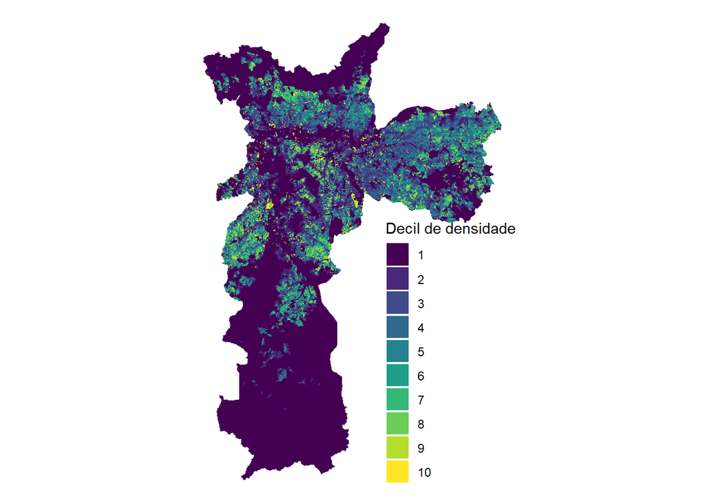

```r
gg <- ggplot() +
  geom_sf(data = censo %>%
            mutate(densidade = v0001/area_setor,
                   decil = ntile(densidade, 10)),
          aes(fill = factor(decil)), color = NA) +
  scale_fill_viridis_d() +
  labs(fill = "Decil de densidade") +
  theme_void() +
  theme(legend.position = c(.8, .3))

ggsave("tex/imagens/mapa.pdf", gg, width = 7, height = 12)
gg
```

```r
censo %>%
  st_drop_geometry() %>%
  summarize("Total de Pessoas" = sum(v0001),
            "Total de Domicílios" = sum(v0002),
            "Total de Domicílios Particulares Ocupados" = sum(v0007)) %>%
  pivot_longer(everything(), names_to = "Variável", values_to = "Valor") %>%
  gt()
```

| Variável | Valor |
| --- | --- |
| Total de Pessoas | 11451999 |
| Total de Domicílios | 4996529 |
| Total de Domicílios Particulares Ocupados | 4316336 |

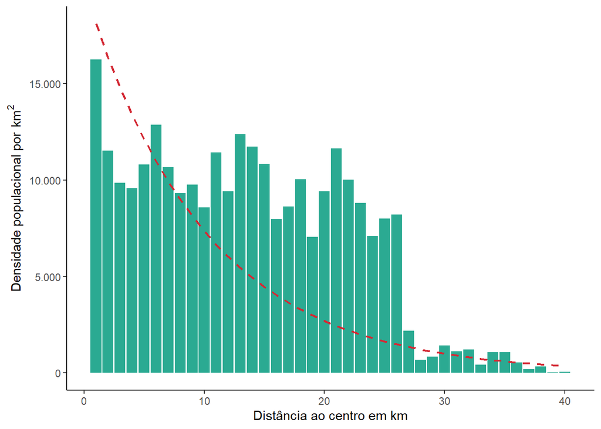

```r
gg <- censo %>%
  mutate(distancia_centro = st_distance(geometry,
                                        read_sf("dados/distrito/SIRGAS_SHP_distrito.shp") %>%
                                          st_set_crs("epsg:31983") %>%
                                          filter(ds_nome == "SE")) %>%
           as.numeric() %>%
           cut(breaks = 10^3*(0:40), labels = FALSE)) %>%
  st_drop_geometry() %>%
  group_by(distancia_centro) %>%
  summarize(densidade = sum(v0001) / sum(as.numeric(area_setor) / 10^6)) %>%
  mutate(teorico = 2*10^4*exp(-distancia_centro/10)) %>%
  ggplot(aes(x = distancia_centro)) +
  geom_col(aes(y = densidade), fill = "#2BAA92FF") +
  geom_line(aes(y = teorico), lwd = .8, linetype = "dashed", color = "#D32934FF") +
  scale_y_continuous(labels = scales::comma_format(big.mark = ".")) +
  scale_x_continuous(labels = scales::comma_format(big.mark = ".")) +
  labs(x = "Distância ao centro em km",
       y = expression("Densidade populacional por" ~ km^2)) +
  theme_classic()

ggsave("tex/imagens/densidade_distcentro.pdf", gg, width = 5, height = 3)
gg
```

# Base de Dados do IPTU

A base de dados do IPTU (Imposto Predial e Territorial Urbano) é uma fonte abrangente de informações sobre imóveis urbanos dentro do município. Essa base é considerada completa, pois abrange todos os imóveis sujeitos à tributação do IPTU, representando uma fonte confiável e abrangente de informações sobre a propriedade urbana. Propriedades que não foram construídas dentro da legalidade não constam nessa base.

O número do contribuinte, utilizado para identificar exclusivamente cada imóvel na base de dados do IPTU, é representado diretamente pelo SQL, sendo essencial para consultas e manipulação dos dados relacionados ao imposto predial e territorial urbano. Esse formato permite a integração e cruzamento com outras bases de dados, como a base de lotes, que está georreferenciada, fornecendo informações espaciais adicionais que não estão disponíveis na base do IPTU.

Quando um lote é um condomínio, ou seja, quando não se classifica de acordo com `condominio == "00-0"`, é necessário substituir os múltiplos números de SQL pelo número do condomínio. Isso ocorre porque cada unidade dentro do condomínio pode ser tratada como uma entidade separada para fins tributários, mas para a base de lotes, estão todos juntos.

```r
IPTU <- read.csv("dados/IPTU/IPTU_2024.csv", sep=";", encoding = "latin1") %>%
    as_tibble() %>%
    select(sql = "NUMERO.DO.CONTRIBUINTE",
           condominio = "NUMERO.DO.CONDOMINIO",
           area_terreno = "AREA.DO.TERRENO",
           area_construida = "AREA.CONSTRUIDA",
           area_ocupada = "AREA.OCUPADA",
           pavimentos = "QUANTIDADE.DE.PAVIMENTOS",
           ano_construcao = "ANO.DA.CONSTRUCAO.CORRIGIDO",
           tipo = "TIPO.DE.PADRAO.DA.CONSTRUCAO") %>%

    # Separação do número de contribuinte (SQL) em setor quadra e lote
    mutate(setor =  str_sub(sql, 1, 3),
           quadra = str_sub(sql, 4, 6),

           # Quando o lote é um condomínio, haverá vários SQLs no mesmo lote. CD = Condomínio
           lote = str_sub(sql, 7, 10) %>%
             ifelse(condominio == "00-0", ., paste("CD", str_sub(condominio, 1, 2), sep = "")),

           # Tipo de uso
           residencial = str_detect(tipo, "Residencial"))

IPTU %>%
  modelsummary::datasummary_skim()
```

Unique

Missing Pct.

Mean

SD

Min

Median

Max

area_terreno

9304

0

3546.7

15146.5

1.0

800.0

4307493.0

[figure not shown]

area_construida

6718

0

157.1

1068.9

0.0

102.0

950328.0

[figure not shown]

area_ocupada

5159

0

1276.6

3170.0

0.0

378.0

320000.0

[figure not shown]

pavimentos

52

0

9.4

8.7

0.0

5.0

98.0

[figure not shown]

ano_construcao

127

0

1948.3

283.9

0.0

1987.0

2023.0

[figure not shown]

Todos os empreendimentos não públicos regulares (de acordo com a lei) constam nesta base de dados. A seguir está uma análise de quais são estes tipos. O tipo de interesse para esta análise é apenas os residenciais.

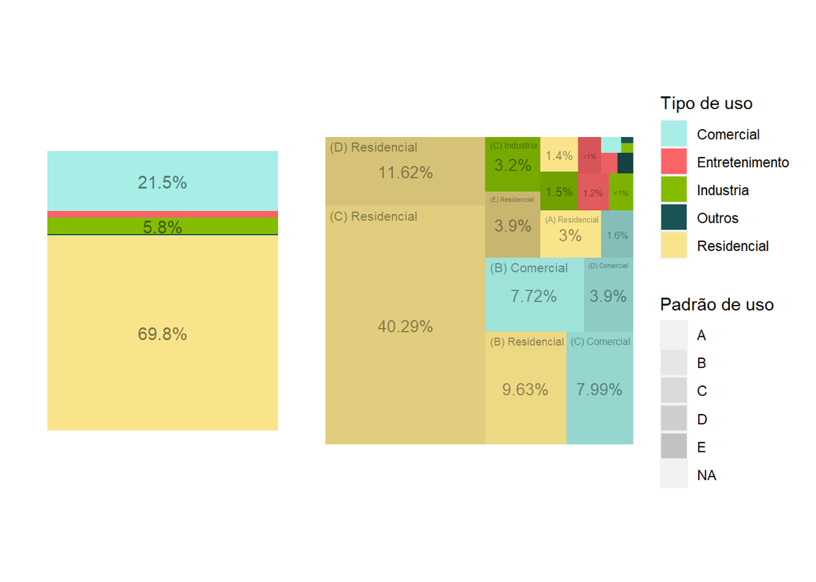

```r
gg.right <- IPTU %>%
  mutate(uso = case_when(str_detect(tipo, "Residencial") ~ "Residencial",
                         str_detect(tipo, "Comercial") ~ "Comercial",
                         str_detect(tipo, "Oficina") ~ "Industria",
                         str_detect(tipo, "TERRENO") ~ "Terreno",
                         str_detect(tipo, "Clube") ~ "Entretenimento",
                         .default = "Outros") %>% as.factor(),
         padrao = case_when(str_detect(tipo, "A$") ~ "A",
                            str_detect(tipo, "B$") ~ "B",
                            str_detect(tipo, "C$") ~ "C",
                            str_detect(tipo, "D$") ~ "D",
                            str_detect(tipo, "E$") ~ "E",
                            .default = "NA"),
         nome = paste("(", padrao, ") ", uso, sep = "")) %>%
  group_by(uso, padrao, nome) %>%
  summarize(area = sum(area_construida)) %>%
  ungroup() %>%
  mutate(percentual = area * 100/ sum(area, na.rm = TRUE),
         texto = case_when(percentual < 1 ~ "<1%",
                           percentual < 5 ~ paste(round(percentual,1), "%", sep = ""),
                           .default = paste(round(percentual, 2), "%", sep = "")),
         color = ifelse(uso == "Outros", "white", "black")) %>%
  ggplot() +
  treemapify::geom_treemap(aes(fill = uso, area = area), size = 2, color = NA) +
  treemapify::geom_treemap(aes(alpha = padrao, area = area), fill = "black", color = NA) +
  treemapify::geom_treemap_text(aes(area = area, label = nome, color = color), alpha = .4, grow = FALSE, size = 8) +
  treemapify::geom_treemap_text(aes(area = area, label = texto, color = color),
                                alpha = .4, place = "middle", size = 10) +
  scale_fill_manual(values = c("Residencial" = "#FAE48B",
                               "Comercial" = "#A6EEE6",
                               "Industria" = "#84BD00",
                               "Entretenimento" = "#FB6467",
                               "Outros" = "#1A5354")) +
  scale_alpha_manual(values = c("A" = 0, "B" = .05, "C" = .1, "D" = .15, "E" = .2, "NA" = 0)) +
  scale_color_manual(values = c("black" = "black", "white" = "white")) +
  labs(fill = "Tipo de uso", alpha = "Padrão de uso") +
  theme(aspect.ratio=1)

gg.left <- IPTU %>%
  mutate(uso = case_when(str_detect(tipo, "Residencial") ~ "Residencial",
                         str_detect(tipo, "Comercial") ~ "Comercial",
                         str_detect(tipo, "Oficina") ~ "Industria",
                         str_detect(tipo, "TERRENO") ~ "Terreno",
                         str_detect(tipo, "Clube") ~ "Entretenimento",
                         .default = "Outros") %>% as.factor()) %>%
  group_by(uso) %>%
  summarize(area = sum(area_construida, na.rm = TRUE)) %>%
  ungroup() %>%
  arrange(desc(uso)) %>%
  mutate(percentual = area * 100 / sum(area, na.rm = TRUE),
         texto = ifelse(percentual > 5, paste(round(percentual, 1), "%", sep = ""), ""),
         ytext = (cumsum(area) + lag(cumsum(area)))/ 2) %>%
  ggplot() +
  geom_col(aes(y = area, fill = uso, x = "")) +
  geom_text(aes(y = ytext, fill = uso, x = "", label = texto), alpha = .5) +
  scale_fill_manual(values = c("Residencial" = "#FAE48B",
                               "Comercial" = "#A6EEE6",
                               "Industria" = "#84BD00",
                               "Entretenimento" = "#FB6467",
                               "Outros" = "#1A5354")) +
  theme_void() +
  theme(legend.position = "none")

ggsave("tex/imagens/tree_area_construida.pdf",
       (gg.left | gg.right) +
         plot_layout(widths = c(1,6)),
       width = 6.75, height = 5)

(gg.left | gg.right)
```

Quando há um condomínio com múltiplos contribuintes de IPTU, ele deve ser agregado a nível lote, para que possa ser cruzado com a base de lotes, possibilitando que seja georreferenciada. Todos os contribuintes dentro de um condomínio compartilham das mesmas características de área de terreno, área ocupada, ano de construção e pavimentos, então a mediana funciona para agregar estes dados, mas o máximo, mínimo, média ou pegar o primeiro valor também funcionaria.

```r
IPTU <- IPTU %>%
  # Agregar por SQL
  group_by(setor, quadra, lote) %>%
  summarize(unidades = n(),
            area_terreno = median(area_terreno),
            area_construida = sum(area_construida),
            area_ocupada = median(area_ocupada),
            pavimentos = median(pavimentos),
            ano_construcao = median(ano_construcao),
            residencial = median(residencial)) %>%
  ungroup() %>%
  mutate(CA = area_construida / area_terreno,
         cota_parte = area_terreno / unidades,
         verticalizacao = area_construida / area_ocupada) %>%

  filter(area_ocupada > 0)

IPTU %>%
  filter(residencial == 1) %>%
  modelsummary::datasummary_skim()
```

Unique

Missing Pct.

Mean

SD

Min

Median

Max

unidades

545

0

2.4

16.4

1.0

1.0

2861.0

[figure not shown]

area_terreno

5736

0

248.8

1917.0

6.0

160.0

1442400.0

[figure not shown]

area_construida

12097

0

306.3

1954.9

2.0

120.0

400000.0

[figure not shown]

area_ocupada

3403

0

118.4

407.8

1.0

90.0

200000.0

[figure not shown]

pavimentos

51

0

1.8

1.8

1.0

2.0

52.0

[figure not shown]

ano_construcao

166

0

1981.8

14.6

1800.0

1981.0

2023.0

[figure not shown]

residencial

1

0

1.0

0.0

1.0

1.0

1.0

CA

100483

0

0.9

0.8

0.0

0.8

36.1

[figure not shown]

cota_parte

17359

0

208.3

1624.9

1.5

155.0

1442400.0

[figure not shown]

verticalizacao

53664

0

1.7

1.7

0.0

1.4

180.0

[figure not shown]

```r
IPTU %>%
  mutate(Tipo = ifelse(unidades == 1, "Unidade", "Condomínio")) %>%
  group_by(Tipo) %>%
  summarize("Lotes" = n(),
            "Unidades" = sum(unidades)) %>%
  gt()
```

| Tipo | Lotes | Unidades |
| --- | --- | --- |
| Condomínio | 33116 | 1781971 |
| Unidade | 1255235 | 1255235 |

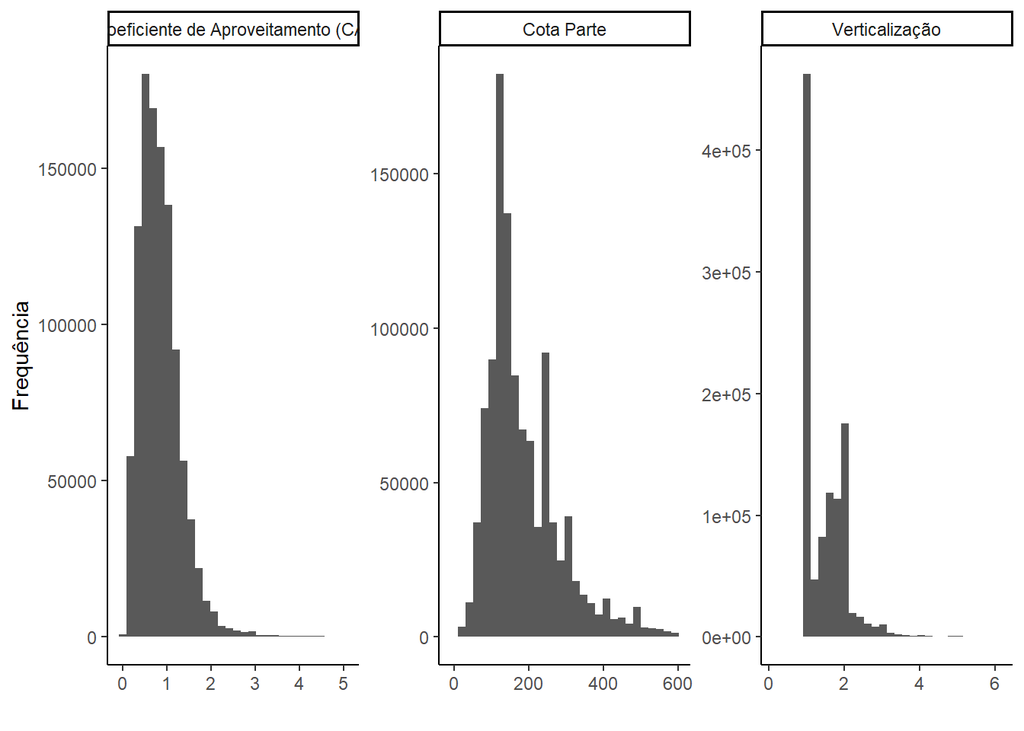

```r
gg <- IPTU %>%
  filter(residencial == 1) %>%
  filter(cota_parte < 600, CA < 5, verticalizacao < 6) %>%
  select("Cota Parte" = cota_parte, "Coeficiente de Aproveitamento (CA)" = CA, "Verticalização" = verticalizacao) %>%
  pivot_longer(everything()) %>%
  ggplot() +
  geom_histogram(aes(x = value)) +
  facet_wrap(~ name, scales = "free") +
  labs(x = "", y = "Frequência") +
  theme_classic()

ggsave("tex/imagens/indicadores.pdf", gg, width = 8, height = 2.75)
gg
```

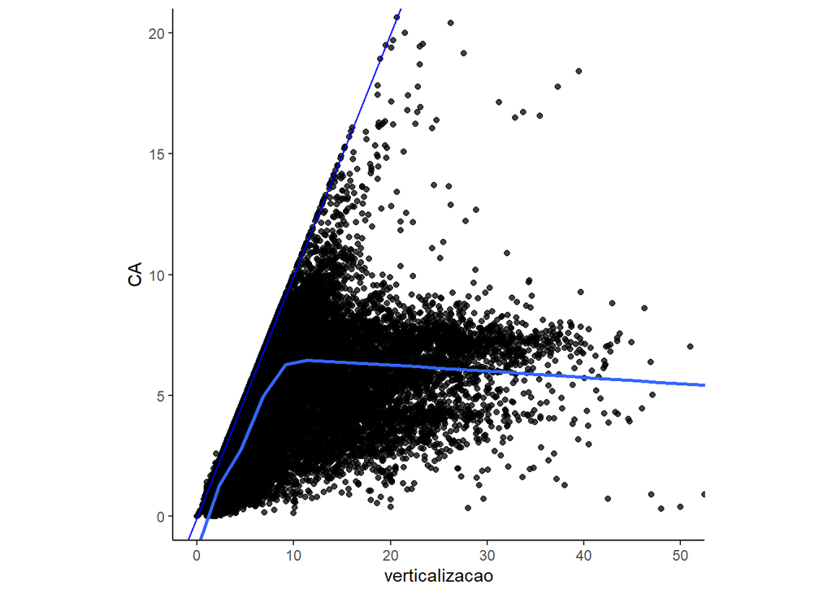

```r
IPTU %>%
  filter(residencial == 1) %>%
  ggplot(aes(x = verticalizacao, y = CA)) +
  geom_point(alpha = .75) +
  geom_abline(intercept = 0, slope = 1, color = "blue") +
  geom_smooth() +
  theme_classic() +
  coord_cartesian(xlim = c(0,50), ylim = c(0,20)) +
  theme(aspect.ratio = 1)
```

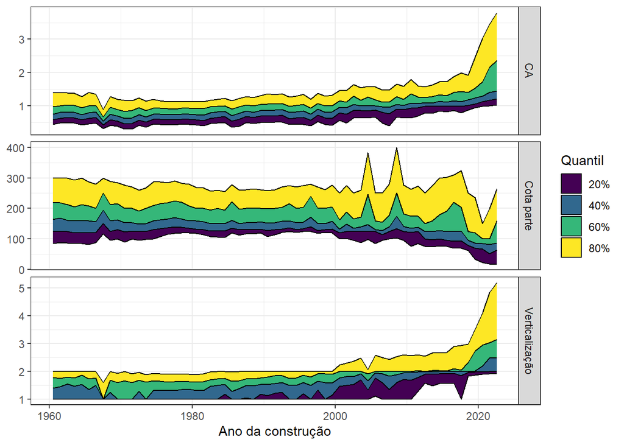

```r
gg <- IPTU %>%
  filter(residencial == 1, !is.na(ano_construcao), ano_construcao > 1950) %>%
  mutate(ano_construcao = ano_construcao %>% round()) %>%
  group_by(ano_construcao) %>%
  # Cria quantis, o primeiro e último são o mínimo e máximo, respectivamente
  summarize(cota_parte = quantile(cota_parte,  0:6/6),
            CA = quantile(CA,  0:6/6),
            verticalizacao = quantile(verticalizacao,  0:6/6)) %>%
  mutate(quantil = row_number() - 1,
         ano_construcao = as.Date(as.character(ano_construcao), format = "%Y")) %>%
  pivot_longer(cota_parte:verticalizacao) %>%
  group_by(ano_construcao, name) %>%
  mutate(ymin = lag(value) %>% replace_na(0)) %>%
  filter(quantil %in% 2:5) %>%
  ggplot() +
  geom_ribbon(aes(x = ano_construcao, ymax = value, ymin = ymin, fill = factor(quantil)), color = "black") +
  facet_grid(rows = "name", scales = "free_y",
             labeller = as_labeller(c("CA" = "CA",
                                      "verticalizacao" = "Verticalização",
                                      "cota_parte" = "Cota parte"))) +
  scale_x_date(limits = as.Date(c("1960", "2022"), format = "%Y")) +
  scale_fill_viridis_d(labels = c("20%", "40%", "60%", "80%")) +
  theme_bw() +
  labs(fill = "Quantil", x = "Ano da construção")

ggsave("tex/imagens/indicadores_tempo.pdf", gg, width = 8, height = 9)
gg
```

# Geosampa

GeoSampa é o portal de mapas e dados geoespaciais da cidade de São Paulo, mantido pela prefeitura. Ele fornece uma vasta gama de informações geográficas, incluindo mapas, dados demográficos, infraestruturas e muito mais. Este portal é uma ferramenta valiosa para pesquisadores, urbanistas e qualquer pessoa interessada em informações espaciais detalhadas sobre a cidade.

https://geosampa.prefeitura.sp.gov.br/

Base de Lotes: No GeoSampa, a base de lotes representa a divisão da cidade em pequenos segmentos, geralmente correspondentes a terrenos individuais ou condomínios. Esta base está organizada de forma que cada bairro tem seu próprio conjunto de dados e os dados de lotes para cada bairro podem ser baixados diretamente do site do GeoSampa em formato zip, contendo arquivos como .shp (shapefile), .dbf (database file), e .shx (index file).

```r
# Extração do zip file com lotes de cada bairro
if (!"zip" %in% list.files(path = "dados/lotes")){
  for (file in list.files(path="dados/lotes/zip", full.names = FALSE) %>%
       str_remove("\\.zip")){
    unzip(paste("dados/lotes/zip/", file, ".zip", sep = ""),
          paste(file, "/", file, ".shp", sep = ""),
          exdir = "dados/lotes/unzip")
    unzip(paste("dados/lotes/zip/", file, ".zip", sep = ""),
          paste(file, "/", file, ".dbf", sep = ""),
          exdir = "dados/lotes/unzip")
    unzip(paste("dados/lotes/zip/", file, ".zip", sep = ""),
          paste(file, "/", file, ".shx", sep = ""),
          exdir = "dados/lotes/unzip")
  }
}
```

```r
# Junção dos shapes dos lotes de cada bairro em uma tabela
lotes <- list.files(path="dados/lotes/unzip", full.names = FALSE) %>%
    paste("dados/lotes/unzip/", ., "/", ., ".shp", sep = "") %>%
    lapply(read_sf) %>%
    bind_rows %>%
    st_set_crs("epsg:31983")
```

Os lotes podem ser classificados de três formas

- Lotes fiscais: apresentam contribuintes do IPTU
- Espaço livre: espaços públicos
- Via de acesso: Ruas fechadas para acesso dentro de uma quadra

Os lotes fiscais podem ser unidades ou condomínios. Um prédio, por exemplo, fica em um único lote, mas dentro pode haver diversas unidades, então se configura como um condomínio. Não é possível saber através dos dados de lotes quantas unidades estão no condomínio, nem alguma forma de discriminá-los.

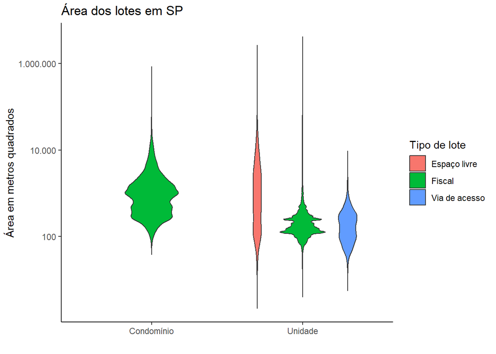

```r
lotes %>%
  mutate(condominio = case_when(lo_condomi == "00" ~ "Unidade",
                                lo_condomi != "00" ~ "Condomínio"),
         tipo = case_when(lo_tp_lote == "F" ~ "Fiscal",
                          lo_tp_lote == "M" ~ "Espaço livre",
                          lo_tp_lote == "V" ~ "Via de acesso",
                          .default = NA),
         area = st_area(geometry) %>% as.numeric()) %>%
  st_drop_geometry() %>%
  ggplot() +
  geom_violin(aes(x = factor(condominio), y = area, fill = tipo)) +
  scale_y_log10(labels = scales::comma_format(big.mark = ".")) +
  labs(title = "Área dos lotes em SP" , x = "", y = "Área em metros quadrados", fill = "Tipo de lote") +
  theme_classic()
```

Na base de dados de lotes, cada lote é identificado por três componentes principais:

1. Setor (lo_setor): Uma divisão maior dentro do município que agrupa várias quadras.
2. Quadra (lo_quadra): Uma subdivisão dentro de um setor que agrupa vários lotes.
3. Lote (lo_lote): A menor unidade de divisão, que representa um terreno ou uma parcela específica dentro de uma quadra. Essa estrutura de Setor-Quadra-Lote é crucial para identificar de forma única cada lote dentro do município. No código, esses identificadores são utilizados para manipular e cruzar os dados de lotes com outras bases de dados, como a base de IPTU.

```r
lotes <- lotes %>%
 filter(lo_tp_lote == "F") %>% # Seleção apenas de lotes fiscais
  mutate(lo_lote = ifelse(lo_lote == "0000", paste("CD", lo_condomi, sep = ""), lo_lote)) %>%
  select(setor = lo_setor, quadra = lo_quadra, lote = lo_lote)
```

```r
quadras <- read_sf("dados/quadras/SIRGAS_SHP_quadraMDSF.shp") %>%
  st_set_crs("epsg:31983") %>%
  filter(qd_tipo == "F") %>% # Apenas quadras fiscais
  select(setor = qd_setor, quadra = qd_fiscal) %>%
  group_by(setor, quadra) %>%
  summarize(geometry = st_union(geometry)) %>%
  ungroup()
```

```r
setores <- read_sf("dados/setor/SIRGAS_SHP_setorfiscal.shp") %>%
  st_set_crs("epsg:31983") %>%
  select(setor = st_codigo) %>%
  group_by(setor) %>%
  summarize(geometry = st_union(geometry)) %>%
  ungroup()
```

# Join IPTU - GeoSampa

```r
# Join dos lotes com IPTU com base no SQL
IPTU.lote <- IPTU %>%
  filter(residencial == 1) %>%
  left_join(lotes, by = join_by(setor, quadra, lote)) %>%
  ungroup()

IPTU.lote %>%
  modelsummary::datasummary_skim()
```

Unique

Missing Pct.

Mean

SD

Min

Median

Max

unidades

545

0

2.4

16.4

1.0

1.0

2861.0

[figure not shown]

area_terreno

5736

0

248.8

1917.0

6.0

160.0

1442400.0

[figure not shown]

area_construida

12097

0

306.3

1954.9

2.0

120.0

400000.0

[figure not shown]

area_ocupada

3403

0

118.4

407.8

1.0

90.0

200000.0

[figure not shown]

pavimentos

51

0

1.8

1.8

1.0

2.0

52.0

[figure not shown]

ano_construcao

166

0

1981.8

14.6

1800.0

1981.0

2023.0

[figure not shown]

residencial

1

0

1.0

0.0

1.0

1.0

1.0

CA

100483

0

0.9

0.8

0.0

0.8

36.1

[figure not shown]

cota_parte

17359

0

208.3

1624.9

1.5

155.0

1442400.0

[figure not shown]

verticalizacao

53664

0

1.7

1.7

0.0

1.4

180.0

[figure not shown]

```r
IPTU.quadra <- IPTU %>%
  filter(residencial == 1) %>%
  group_by(setor, quadra) %>%
  summarize(unidades = sum(unidades),
            area_construida = sum(area_construida),
            verticalizacao = weighted.mean(verticalizacao, area_terreno),
            area_terreno = sum(area_terreno)) %>%
  left_join(quadras, by = join_by(setor, quadra)) %>%
  ungroup()

IPTU.quadra %>%
  modelsummary::datasummary_skim()
```

Unique

Missing Pct.

Mean

SD

Min

Median

Max

unidades

976

0

77.6

160.6

1.0

34.0

4762.0

area_construida

15166

0

9976.7

19124.6

8.0

4813.0

521949.0

verticalizacao

33567

0

2.4

3.0

0.9

1.5

81.6

[figure not shown]

area_terreno

14846

0

8104.0

13914.7

50.0

6029.0

1447291.0

[figure not shown]

```r
IPTU.setor <- IPTU %>%
  filter(residencial == 1) %>%
  group_by(setor) %>%
  summarize(unidades = sum(unidades),
            area_construida = sum(area_construida),
            verticalizacao = weighted.mean(verticalizacao, area_terreno),
            area_terreno = sum(area_terreno)) %>%
  left_join(setores, by = join_by(setor)) %>%
  ungroup()

IPTU.setor %>%
  modelsummary::datasummary_skim()
```

|  | Unique | Missing Pct. | Mean | SD | Min | Median | Max |  |
| --- | --- | --- | --- | --- | --- | --- | --- | --- |
| unidades | 168 | 0 | 15827.8 | 9045.2 | 133.0 | 13694.0 | 46511.0 |  |
| area_construida | 168 | 0 | 2034480.2 | 1287662.5 | 16480.0 | 1682702.5 | 6822366.0 |  |
| verticalizacao | 168 | 0 | 3.5 | 2.2 | 1.1 | 2.7 | 12.5 |  |
| area_terreno | 168 | 0 | 1652592.8 | 1064452.3 | 30130.0 | 1410261.5 | 5087896.0 |  |

```r
list(IPTU %>% filter(residencial == 1) %>% mutate(base = "bruta"),
     IPTU.setor  %>% mutate(base = "Setor")  %>% filter(!geometry %>% st_is_empty()),
     IPTU.quadra %>% mutate(base = "Quadra") %>% filter(!geometry %>% st_is_empty()),
     IPTU.lote   %>% mutate(base = "Lote")   %>% filter(!geometry %>% st_is_empty())) %>%
  lapply(function(x) x %>%
           group_by(base) %>%
           summarize(unidades = sum(unidades))) %>%
  bind_rows %>%
  pivot_wider(names_from = base, values_from = unidades) %>%
  pivot_longer(2:4) %>%
  mutate(missing = bruta - value,
         missing_percent = (100 *missing / bruta) %>% round(2) %>% paste("%")) %>%
  select("Critério de join" = name,
         "Erros (unidades)" = missing,
         "Percentual de erro" = missing_percent) %>%
  gt()
```

| Critério de join | Erros (unidades) | Percentual de erro |
| --- | --- | --- |
| Setor | 0 | 0 % |
| Quadra | 820 | 0.03 % |
| Lote | 44319 | 1.67 % |

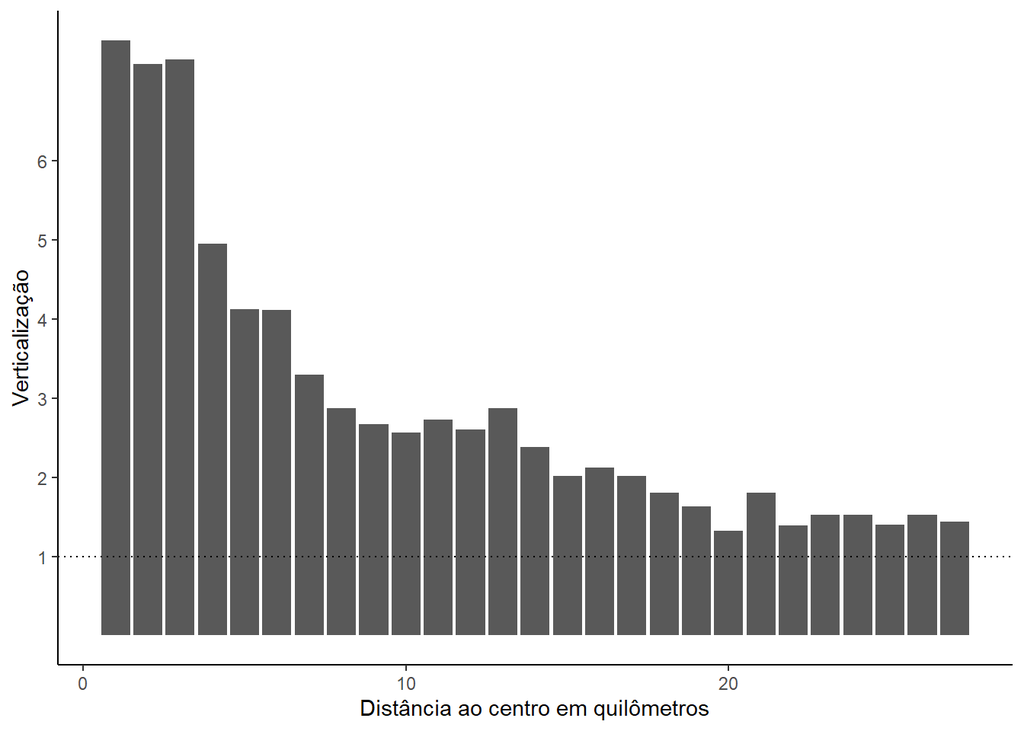

```r
gg <- IPTU.lote %>%
  mutate(distancia_centro = st_distance(geometry,
                                        read_sf("dados/distrito/SIRGAS_SHP_distrito.shp") %>%
                                          st_set_crs("epsg:31983") %>%
                                          filter(ds_nome == "SE")) %>%
           as.numeric() %>%
           cut(breaks = 10^3*(0:40), labels = FALSE)) %>%
  st_drop_geometry() %>%
  group_by(distancia_centro) %>%
  summarize(verticalizacao = weighted.mean(verticalizacao, area_terreno)) %>%
  ggplot(aes(x = distancia_centro, y = verticalizacao)) +
  geom_col() +
  geom_hline(yintercept = 1, linetype = "dotted") +
  labs(x = "Distância ao centro em quilômetros",
       y = "Verticalização") +
  scale_y_continuous(breaks = (1:6)) +
  theme_classic()

ggsave("tex/imagens/verticalizacao.pdf", gg, width = 6, height = 4)
gg
```

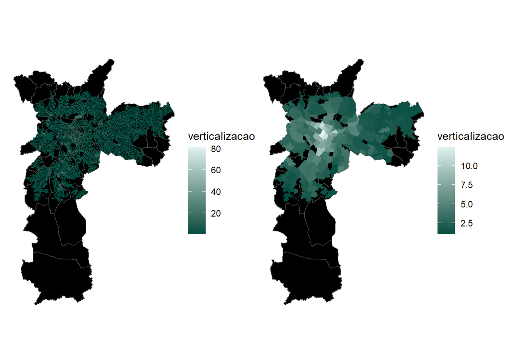

```r
gg.lotes <- IPTU.quadra %>%
  ggplot() +
  geom_sf(data = distrito, fill = "black") +
  geom_sf(aes(fill = verticalizacao, geometry = geometry), color = NA) +
  theme_void() +
  scale_fill_gradient(low = "#004D40FF", high = "#E0F2F1FF")

gg.setor <- IPTU.setor %>%
  ggplot() +
  geom_sf(data = distrito, fill = "black") +
  geom_sf(aes(fill = verticalizacao, geometry = geometry), color = NA) +
  theme_void() +
  scale_fill_gradient(low = "#004D40FF", high = "#E0F2F1FF")

ggsave("tex/imagens/mapa_verticalizacao.pdf",
       (gg.lotes | gg.setor), width = 20, height = 20)

(gg.lotes | gg.setor)
```

# Join IPTU - Censo

O processo de cruzamento foi realizado com base na intersecção das geometrias dos setores censitários e dos lotes do IPTU. Cada setor censitário e cada lote do IPTU possui uma geometria associada, representando sua área geográfica no mapa. Ao cruzar essas geometrias, é possível identificar quais lotes estão contidos em cada setor censitário e vice-versa.

É importante destacar que, em casos onde um lote foi dividido entre dois ou mais setores censitários, ocorrerá uma intersecção em ambas as áreas. Para lidar com essa situação, foi calculado o percentual da área do lote que está contida em cada setor censitário.

```r
# Join dados do IPTU com do Censo através da intersecção das geometrias
IPTU.censo <- censo %>%
  st_intersection(IPTU.lote %>% st_as_sf()) %>%
  as_tibble() %>%
  rename(geometria_intersec = geometry) %>%

  # Retomada das geometrias do setor e lotes
  left_join(censo %>%
              as_tibble() %>%
              select(id_setor_censitario,
                     geometria_setor_censitario = geometry),
            by = join_by(id_setor_censitario)) %>%
  left_join(IPTU.lote %>%
              as_tibble() %>%
              select(setor, quadra, lote,
                     geometria_lote = geometry),
            by = join_by(setor, quadra, lote)) %>%

  # Cálculo de quanto % do lote está dentro do setor
  mutate(percent_intersec = as.numeric(st_area(geometria_intersec) / st_area(geometria_lote)))

IPTU.censo %>%
  modelsummary::datasummary_skim()
```

Unique

Missing Pct.

Mean

SD

Min

Median

Max

v0001

1120

0

524.4

202.6

0.0

511.0

2221.0

[figure not shown]

v0002

543

0

227.8

87.1

0.0

222.0

1372.0

[figure not shown]

v0003

538

0

227.5

87.1

0.0

221.0

1371.0

[figure not shown]

v0004

24

0

0.2

1.0

0.0

0.0

170.0

[figure not shown]

v0005

11463

0

2.7

0.3

0.0

2.7

8.0

[figure not shown]

v0006

6421

0

13.4

10.3

0.0

11.2

100.0

[figure not shown]

v0007

471

0

194.7

72.7

0.0

190.0

950.0

[figure not shown]

area_setor

18531

0

52804.2

74529.5

196.3

41868.0

6945494.4

[figure not shown]

unidades

541

0

3.7

33.0

1.0

1.0

2861.0

[figure not shown]

area_terreno

5624

0

326.2

3606.1

6.0

162.0

1442400.0

[figure not shown]

area_construida

11985

0

460.5

4038.2

2.0

120.0

400000.0

[figure not shown]

area_ocupada

3350

0

140.3

1052.4

1.0

90.0

200000.0

[figure not shown]

pavimentos

51

0

1.9

2.2

1.0

2.0

52.0

[figure not shown]

ano_construcao

165

0

1981.7

14.6

1800.0

1981.0

2023.0

[figure not shown]

residencial

1

0

1.0

0.0

1.0

1.0

1.0

CA

99679

0

0.9

0.9

0.0

0.8

36.1

[figure not shown]

cota_parte

17099

0

240.4

2779.6

1.5

156.0

1442400.0

[figure not shown]

verticalizacao

53205

0

1.7

2.0

0.1

1.4

180.0

[figure not shown]

percent_intersec

285710

0

0.9

0.2

0.0

1.0

96.6

[figure not shown]

Teoricamente o número de domicílios deveria ser próximo do número de unidades habitacionais enunciadas pelo IPTU. Caso haja mais unidades habitacionais do que domicílios, houve algum equívoco na medição do censo, visto que entre domicílios não contam apenas os ocupados. Caso haja mais domicílios, há unidades que não são contribuintes do IPTU. O que é preocupante é que casos em que o número é diferente não são exceções.

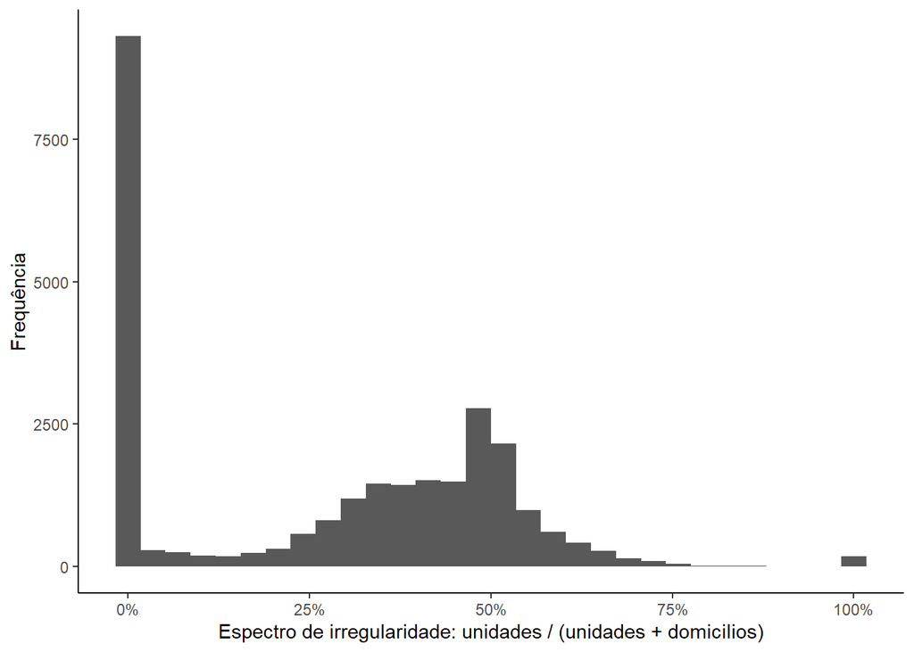

```r
gg <- censo %>%
  st_drop_geometry() %>%
  select(id_setor_censitario, domicilios = v0002) %>%
  left_join(IPTU.censo %>%
              st_drop_geometry() %>%
              filter(residencial == 1) %>%
              group_by(id_setor_censitario) %>%
              summarize(unidades = sum(unidades * percent_intersec))) %>%
  mutate(unidades = replace_na(unidades, 0)) %>%
  mutate(espectro_irregularidade = unidades / (unidades + domicilios)) %>%
  ggplot() +
  geom_histogram(aes(x = espectro_irregularidade)) +
  labs(x = "Espectro de irregularidade: unidades / (unidades + domicilios)", y = "Frequência") +
  theme_classic() +
    theme(plot.caption = element_text(hjust = 0)) +
  scale_x_continuous(labels = scales::percent)


ggsave("tex/imagens/disparidade_censoIPTU.pdf", gg, width = 7, height = 3)
gg
```

Alguns setores censitários não encontram pares na base de lotes. Isso acontece principalmente por conta de loteamentos irregulares e favelas, que não são contribuintes do IPTU, e, portanto, não constam na base. Isso não prejudica a análise, pois estes loteamentos não dependem da regulamentação urbana, então mudanças nos instrumentos e indicadores não impactariam essas regiões.

Outras falhas decorrem do erro do join da base do IPTU com lotes, como apontado anteriormente, mas estes casos são negligenciáveis.

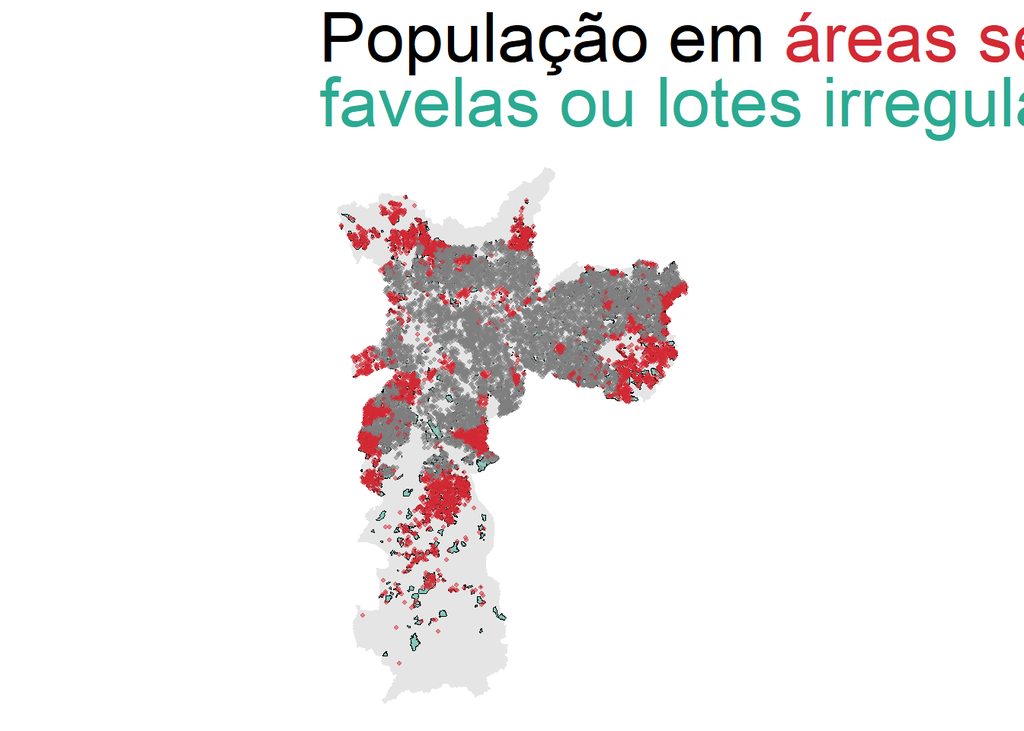

```r
distrito <- read_sf("dados/distrito/SIRGAS_SHP_distrito.shp") %>% st_set_crs("epsg:31983")
lotes_irregulares <- read_sf("dados/lotes_irregulares/SIRGAS_SHP_loteamento.shp") %>%
  st_set_crs("epsg:31983")
favela <- read_sf("dados/favela/SIRGAS_SHP_favela.shp") %>%
  st_set_crs("epsg:31983")


censo.pontos <- censo %>%
  select(id_setor_censitario, geometry, pessoas = v0001) %>%

  # Um ponto a cada 1.000 pessoas
  mutate(pontos = pessoas %/% 1000 + (runif(length(pessoas)) * 1000 < pessoas %% 1000)) %>%
  select(-pessoas) %>%
  as_tibble() %>%
  left_join(
            # Seleção dos setores censitários que não apresentam nenhum contribuinte do IPTU
            censo %>%
              anti_join(IPTU.censo) %>%
              st_drop_geometry() %>%
              select(id_setor_censitario) %>%
              mutate(erro = TRUE)) %>%
  mutate(erro = replace_na(erro, FALSE)) %>%
  filter(pontos > 0) %>%
  mutate(samples = purrr::map2(geometry, pontos, ~st_sample(.x, size = .y))) %>%
  unnest(cols = samples) %>%
  as_tibble()

gg <- censo.pontos %>%
  ggplot() +
  geom_sf(data = distrito, color = NA) +
  geom_sf(data = st_union(favela %>% st_union() %>% st_buffer(10),
                          lotes_irregulares %>% st_union() %>% st_buffer(10)),
          aes(fill = "Favelas e lotes irregulares"),
        color = "black", size = .1, alpha = .5) +
  geom_sf(aes(geometry = samples, color = erro), alpha = .5, size = .8) +
  scale_color_manual(values = c("FALSE" = NA,#248232
                               "TRUE" = "#D32934FF"),
                     labels = NULL) +
  scale_fill_manual("", values = c("Favelas e lotes irregulares" = "#2BAA92FF")) +
  labs(title = "<span style='font-size: 34pt;'>População em <span style = 'color:#D32934FF;'>áreas sem registro de IPTU</span> geralmente estão em <br><span style = 'color:#2BAA92FF;'>favelas ou lotes irregulares</span> (cada ponto representa 1000 pessoas)</span>") +
  theme_void() +
  theme(plot.title = element_markdown(), legend.position = "none")

# scale_colour_paletteer_d("lisa::AndyWarhol_2")

ggsave("tex/imagens/mapa_pontos.pdf", gg, width = 16, height = 20)
gg
```

# Análise de resultados via join

```r
df <- IPTU.censo %>%
  filter(residencial == 1) %>%

  st_drop_geometry() %>%

  group_by(id_setor_censitario) %>%
  summarize(# Setor censitário
            populacao = median(v0001),
            area_setor = median(area_setor) %>% as.numeric(),
            domicilios = median(v0002),
            domicilios_ocupados = median(v0007),

            # Lote
            unidades = sum(unidades * percent_intersec),
            area_terreno = sum(area_terreno * percent_intersec),
            area_construida = sum(area_construida * percent_intersec),
            area_ocupada = sum(area_ocupada * percent_intersec),
            ) %>%

  mutate(densidade = populacao * 10 ^ 6 / area_setor,
         cota_parte = area_terreno / unidades,
         CA = area_construida / area_terreno,
         verticalizacao = area_construida / area_ocupada,
         espectro_irregularidade = unidades / (unidades + domicilios))

modelsummary::datasummary_skim(df)
```

Unique

Missing Pct.

Mean

SD

Min

Median

Max

populacao

1120

0

420.0

213.4

0.0

397.0

2221.0

[figure not shown]

area_setor

18531

0

37267.5

109998.2

196.3

24549.0

6945494.4

[figure not shown]

domicilios

543

0

189.6

88.1

0.0

182.0

1372.0

[figure not shown]

domicilios_ocupados

471

0

162.5

75.3

0.0

156.0

950.0

[figure not shown]

unidades

18524

0

141.1

97.1

0.0

130.1

1343.0

[figure not shown]

area_terreno

18531

0

14702.9

18405.7

0.0

11595.9

1445351.6

[figure not shown]

area_construida

18531

0

18094.3

13503.4

0.0

15739.1

163349.7

[figure not shown]

area_ocupada

18531

0

7008.5

6150.2

0.0

5626.0

64738.0

densidade

18341

0

28519.9

36697.1

0.0

17034.3

1162304.8

cota_parte

18156

0

1282.3

14374.8

1.8

133.4

516201.6

CA

18238

0

2.3

2.4

0.0

1.0

27.5

[figure not shown]

verticalizacao

17941

0

4.7

5.5

1.0

1.8

77.4

[figure not shown]

espectro_irregularidade

18360

0

0.4

0.2

0.0

0.4

1.0

[figure not shown]

```r
df %>%
  select(id_setor_censitario, populacao, domicilios, unidades, area_setor) %>%
  bind_rows(censo %>%
              st_drop_geometry() %>%
              select(id_setor_censitario, populacao = v0001, domicilios = v0002, area_setor) %>%
              mutate(unidades = 0) %>%
              anti_join(df %>% select(id_setor_censitario))) %>%
  filter(populacao > 0) %>%
  mutate(densidade = populacao/area_setor,
         taxa_irregular = (domicilios - unidades) / domicilios,
         espectro_irregularidade = unidades / (unidades + domicilios)) %>%
  lm(log(densidade) ~ espectro_irregularidade, .) %>%
  summary()
```

```
##
## Call:
## lm(formula = log(densidade) ~ espectro_irregularidade, data = .)
##
## Residuals:
##      Min       1Q   Median       3Q      Max
## -11.0873  -0.4522   0.0812   0.7049   4.1956
##
## Coefficients:
##                         Estimate Std. Error  t value Pr(>|t|)
## (Intercept)             -4.10609    0.01168 -351.450  < 2e-16 ***
## espectro_irregularidade  0.14028    0.03279    4.278 1.89e-05 ***
## ---
## Signif. codes:  0 '***' 0.001 '**' 0.01 '*' 0.05 '.' 0.1 ' ' 1
##
## Residual standard error: 1.224 on 26833 degrees of freedom
## Multiple R-squared:  0.0006816,  Adjusted R-squared:  0.0006443
## F-statistic:  18.3 on 1 and 26833 DF,  p-value: 1.893e-05
```

```r
modelo1 <- df %>%
  lm(densidade ~ cota_parte + verticalizacao + CA, data = .) %>%
  summary()

modelo2 <- df %>%
  filter(abs(espectro_irregularidade - .5) < .25) %>%
  lm(densidade ~ cota_parte + verticalizacao + CA, data = .) %>%
  summary()

modelo3 <- df %>%
  filter(abs(espectro_irregularidade - .5) < .1) %>%
  lm(densidade ~ cota_parte + verticalizacao + CA, data = .) %>%
  summary()

modelsummary::modelsummary(
  list("Todos setores" = modelo1, "Balanço entre 25% e 75%" = modelo2, "Balanço entre 40% e 60%" = modelo3),
  gof_omit = "RMSE", estimate = "{estimate} {stars}",
  statistic = "({std.error})")
```

|  | Todos setores | Balanço entre 25% e 75% | Balanço entre 40% e 60% |
| --- | --- | --- | --- |
| (Intercept) | 8603.264 *** | 4242.744 *** | 348.108 |
|  | (311.878) | (347.853) | (608.823) |
| cota_parte | 0.095 *** | −0.018 | −4.176 * |
|  | (0.016) | (0.057) | (1.712) |
| verticalizacao | 1058.806 *** | 1146.076 *** | 1283.914 *** |
|  | (59.059) | (61.902) | (76.170) |
| CA | 6524.131 *** | 7221.037 *** | 7874.627 *** |
|  | (132.933) | (138.888) | (171.647) |
| Num.Obs. | 18531 | 15616 | 9363 |
| R2 | 0.314 | 0.374 | 0.410 |
| R2 Adj. | 0.314 | 0.374 | 0.409 |

```r
modelsummary::modelsummary(list("Todos setores" = modelo1,
                                "Até 50% de irregularidade" = modelo2,
                                "Até 20% de irregularidade" = modelo3),
                                 gof_omit = "RMSE", estimate = "{estimate} {stars}",
                                 statistic = "({std.error})",
                                 output = "gt") %>%
  tab_spanner(label = "Variável dependente: densidade populacional", columns = 2:4) %>%
  tab_footnote("Espectro de irregularidade é definido como unidades / (unidades + domicílios)") %>%
  gtsave("tex/tabelas/regressao.tex", as_latex = TRUE)
```

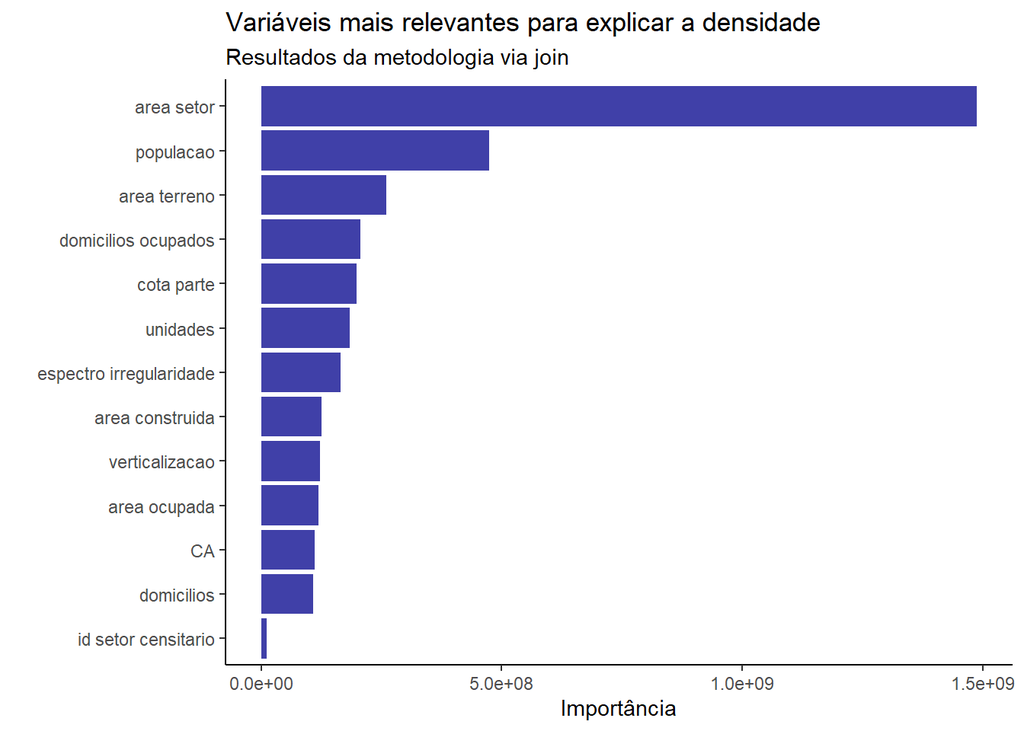

```r
split <- rsample::initial_split(df, prop = 0.7)
train <- rsample::training(split)
test <- rsample::testing(split)

rf_model <- ranger::ranger(densidade ~ .,
                     data = train, num.trees = 5000, importance = "permutation")

var.importance <- ranger::importance(rf_model)
gg <- ggplot(NULL, aes(x = var.importance,
                 y = fct_reorder(names(var.importance) %>% str_replace_all("_", " "),
                                 var.importance))) +
    geom_col(fill = "darkblue", alpha = 0.75) +
    labs(x = "Importância", y = "", title = "Variáveis mais relevantes para explicar a densidade",
         subtitle = "Resultados da metodologia via join") +
    theme_classic()

ggsave("tex/imagens/importancia.pdf", gg, width = 7, height = 4)

gg
```

```r
modelo1 <- df %>%
  filter(abs(espectro_irregularidade - .5) < .1) %>%
  lm(densidade ~ cota_parte + verticalizacao + CA, data = .) %>%
  summary()

modelo2 <- df %>%
  filter(abs(espectro_irregularidade - .5) < .1) %>%
  lm(densidade ~ cota_parte + verticalizacao + CA + area_setor, data = .) %>%
  summary()

modelo3 <- df %>%
  filter(abs(espectro_irregularidade - .5) < .1) %>%
  mutate(area_setor_quad = area_setor^2) %>%
  lm(densidade ~ cota_parte + verticalizacao + CA + area_setor + area_setor_quad, data = .) %>%
  summary()

resultado <- modelsummary::modelsummary(
  list(modelo1, modelo2, modelo3),
  gof_omit = "RMSE", estimate = "{estimate} {stars}",
  statistic = NULL)


resultado
```

|  | (1) | (2) | (3) |
| --- | --- | --- | --- |
| (Intercept) | 348.108 | 2666.857 *** | 5509.428 *** |
| cota_parte | −4.176 * | −0.743 | 2.723 |
| verticalizacao | 1283.914 *** | 1222.791 *** | 1148.769 *** |
| CA | 7874.627 *** | 7685.476 *** | 7455.565 *** |
| area_setor |  | −0.049 *** | −0.114 *** |
| area_setor_quad |  |  | 0.000 *** |
| Num.Obs. | 9363 | 9363 | 9363 |
| R2 | 0.410 | 0.415 | 0.420 |
| R2 Adj. | 0.409 | 0.414 | 0.420 |

# Raster

```r
geoms.IPTU <- IPTU.lote %>%
  filter(! st_is_empty(geometry)) %>%
  st_as_sf() %>%
  mutate(area = st_area(geometry) %>% as.numeric()) %>%
  select(id = setor, area, unidades, area_construida, area_ocupada, area_terreno)

geoms.censo <- censo %>%
  mutate(area = st_area(geometry) %>% as.numeric()) %>%
  select(id = id_setor_censitario, area, populacao = v0001, domicilios = v0002)

bbox <- st_bbox(geoms.censo)

raster <- raster::raster(xmn = bbox["xmin"], xmx = bbox["xmax"], ymn = bbox["ymin"], ymx = bbox["ymax"],
            res = 800, crs = st_crs(geoms.censo)$proj4string, vals = NA)
```

```r
result.IPTU <- exact_extract(raster, geoms.IPTU, include_xy = T,
                             include_cols = c("id", "area", "unidades", "area_construida", "area_ocupada",
                                              "area_terreno"),
                             force_df = T, coverage_area = T, progress = F) %>%
  bind_rows %>%
  mutate(percent_intersect = coverage_area / area,
         across(unidades:area_terreno, ~ .x * percent_intersect)) %>%
  group_by(x, y) %>%
  summarize(unidades = sum(unidades),
            area_ocupada = sum(area_ocupada),
            area_construida = sum(area_construida),
            area_terreno = sum(area_terreno)) %>%
  ungroup() %>%
  mutate(cota_parte = area_terreno / unidades,
         CA = area_construida / area_terreno,
         verticalizacao = area_construida / area_ocupada)

result.censo <- exact_extract(raster, geoms.censo, include_xy = T,
                        include_cols = c("id", "area", "populacao", "domicilios"),
                        force_df = T, coverage_area = T, progress = F) %>%
  bind_rows %>%
  mutate(percent_intersect = coverage_area / area,
         across(c(area, populacao, domicilios), ~ .x * percent_intersect)) %>%
  group_by(x, y) %>%
  summarize(populacao = sum(populacao),
            area = sum(area),
            domicilios = sum(domicilios)) %>%
  mutate(densidade = populacao * 10^6 / area)

result <- full_join(result.IPTU, result.censo) %>%
  mutate(espectro_irregularidade = unidades / (unidades + domicilios))

result %>%
  modelsummary::datasummary_skim()
```

Unique

Missing Pct.

Mean

SD

Min

Median

Max

x

59

0

331929.5

11037.7

313794.9

329794.9

360194.9

y

91

0

7383596.5

18725.5

7343788.7

7388588.7

7415788.7

[figure not shown]

unidades

1256

52

2083.5

2099.4

0.0

1733.9

21056.9

area_ocupada

1256

52

103486.6

64038.7

1.5

113195.8

251213.6

area_construida

1256

52

267192.3

267862.6

1.5

216295.9

2321166.4

area_terreno

1256

52

217116.1

125745.5

7.8

238577.3

840996.4

cota_parte

1254

52

2647.1

42935.6

6.5

140.7

1415766.7

[figure not shown]

CA

1255

52

1.3

1.2

0.0

0.9

9.6

verticalizacao

1246

52

2.6

2.3

1.0

1.8

28.9

[figure not shown]

populacao

2403

0

4367.6

4804.2

0.0

2620.9

29598.3

[figure not shown]

area

1787

0

580109.1

157947.2

0.1

640000.0

640000.0

domicilios

2407

0

1905.6

2154.4

0.0

1108.2

17874.7

[figure not shown]

densidade

2355

0

7338.6

7859.5

0.0

4962.7

46247.3

espectro_irregularidade

1256

52

0.4

0.2

0.0

0.4

1.0

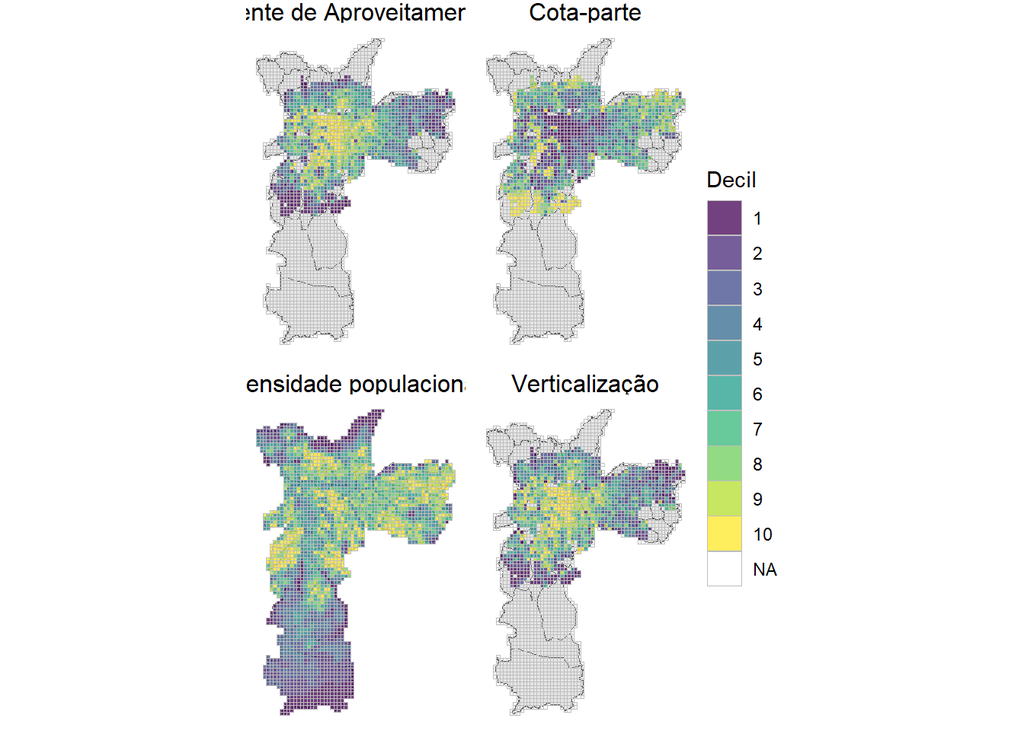

```r
# r <- raster::rasterize(x = result %>% select(x, y), y = raster,
#                        field = result %>%
#                          select(CA, cota_parte, verticalizacao, densidade) %>%
#                          mutate(across(c(CA, cota_parte, verticalizacao), ~ replace_na(.x, 0))))

gg <- result %>%
  pivot_longer(c(CA, cota_parte, verticalizacao, densidade)) %>%
  group_by(name) %>%
  mutate(value = ntile(value, 10) %>% as.factor(),
         name = case_when(name == "CA" ~ "Coeficiente de Aproveitamento (CA)",
                          name == "cota_parte" ~ "Cota-parte",
                          name == "densidade" ~ "Densidade populacional",
                          name == "verticalizacao" ~ "Verticalização",
                          .default = NA)) %>%
  ggplot() +
  geom_sf(data = distrito) +
  geom_tile(aes(x = x, y = y, fill = value), alpha = .75, color = "grey") +
  facet_wrap(~name) +
  theme_void() +
  theme(strip.text = element_text(size = 12)) +
  labs(fill = "Decil") +
  scale_fill_viridis_d()

ggsave("tex/imagens/rasters.pdf", gg, width = 8, height = 12)

gg
```

```r
# (result %>%
#   filter(area > 9*10^5) %>%
#   arrange(desc(densidade)) %>%
#   mutate(top = ifelse(row_number() <= 5, row_number(), NA) %>% as.factor()) %>%
#   ggplot() +
#   geom_sf(data = distrito, color = "grey", aes(text = ds_nome)) +
#   geom_tile(aes(x = x, y = y, fill = top)) +
#   scale_fill_viridis_d() +
#   theme_void()) %>%
#   plotly::ggplotly()
```

[figure not shown]

```r
gg <- result %>%
  drop_na() %>%
  ggplot() +
  geom_sf(data = distrito, color = NA) +
  geom_tile(aes(x = x, y = y, fill = espectro_irregularidade), alpha = .75, color = "grey") +
  theme_void() +
  scale_fill_gradient2(high = "#2F191B", low = "#D32934", mid = "white", na.value = NA,
                       midpoint = .5, limits = c(0,1)) +
  theme(legend.position = c(.8, .35), legend.title = element_markdown(size = 25),
        plot.title = element_markdown(), legend.text = element_text(size = 25),
        legend.key.size = unit(1.75, 'cm')) +
  labs(fill = "Espectro de irregularidade", title = "<span style='font-size: 35pt;'>Áreas com <span style = 'color:#D32934;'>menos domicílios registrados no IPTU, comparados <br>ao censo</span> geralmente estão em regiões afastadas do centro</span>")

ggsave("tex/imagens/balanco_raster.pdf", gg, width = 16, height = 20)

gg
```

# Análise resultados via Raster

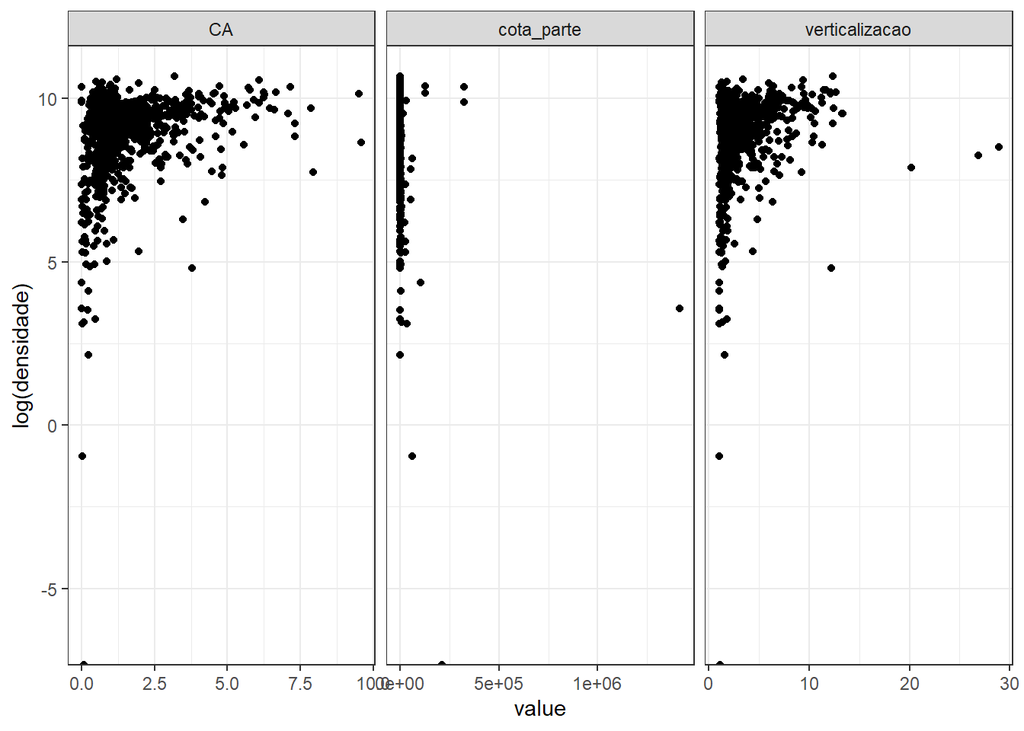

```r
result %>%
  pivot_longer(c(verticalizacao, CA, cota_parte)) %>%
  ggplot(aes(x = value, y = log(densidade))) +
  geom_point() +
  facet_wrap(~name, scales = "free_x") +
  theme_bw()
```

```r
modelo1 <- result %>%
  lm(densidade ~ cota_parte + verticalizacao + CA, data = .) %>%
  summary()

modelo2 <- result %>%
  filter(abs(espectro_irregularidade - .5) < .25) %>%
  lm(densidade ~ cota_parte + verticalizacao + CA, data = .) %>%
  summary()

modelo3 <- result %>%
  filter(abs(espectro_irregularidade - .5) < .1) %>%
  lm(densidade ~ cota_parte + verticalizacao + CA, data = .) %>%
  summary()

modelsummary::modelsummary(
  list("Todos setores" = modelo1, "Até 50% de irregularidade" = modelo2, "Até 20% de irregularidade" = modelo3),
  gof_omit = "RMSE", estimate = "{estimate} {stars}",
  statistic = NULL)
```

|  | Todos setores | Até 50% de irregularidade | Até 20% de irregularidade |
| --- | --- | --- | --- |
| (Intercept) | 11046.375 *** | 11737.452 *** | 8632.310 *** |
| cota_parte | −0.004 | −6.356 *** | −6.973 *** |
| verticalizacao | −249.059 | −138.277 | −48.242 |
| CA | 1211.554 *** | 901.825 ** | 1672.931 *** |
| Num.Obs. | 1255 | 963 | 553 |
| R2 | 0.022 | 0.114 | 0.249 |
| R2 Adj. | 0.020 | 0.112 | 0.245 |

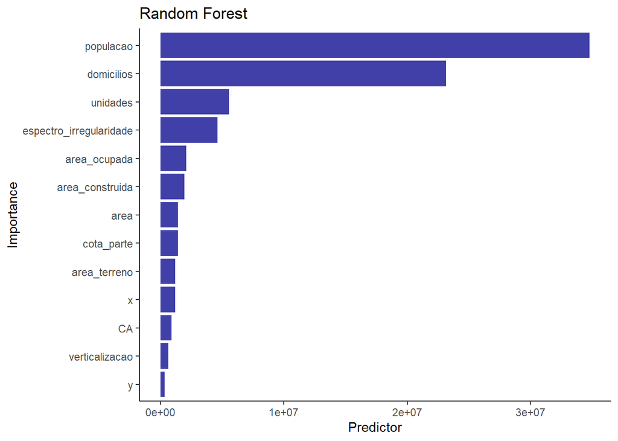

```r
split <- rsample::initial_split(result %>%
                                  drop_na() %>%
                                  filter(area > 63950),
                                prop = 0.7)
train <- rsample::training(split)
test <- rsample::testing(split)

# rf_model <- ranger::ranger(densidade ~ CA + cota_parte + verticalizacao,
#                      data = train, num.trees = 1000, importance = "permutation")
# rf_preds <- predict(rf_model, data = test)$predictions

rf_model_all <- ranger::ranger(densidade ~ .,
                     data = train, num.trees = 5000, importance = "permutation")
rf_preds_all <- predict(rf_model_all, data = test)$predictions

ggplot(NULL, aes(x = rf_model_all$variable.importance,
                 y = fct_reorder(names(rf_model_all$variable.importance),
                                 rf_model_all$variable.importance))) +
    geom_col(fill = "darkblue", alpha = 0.75) +
    labs(x = "Predictor", y = "Importance", title = "Random Forest") +
    theme_classic()
```

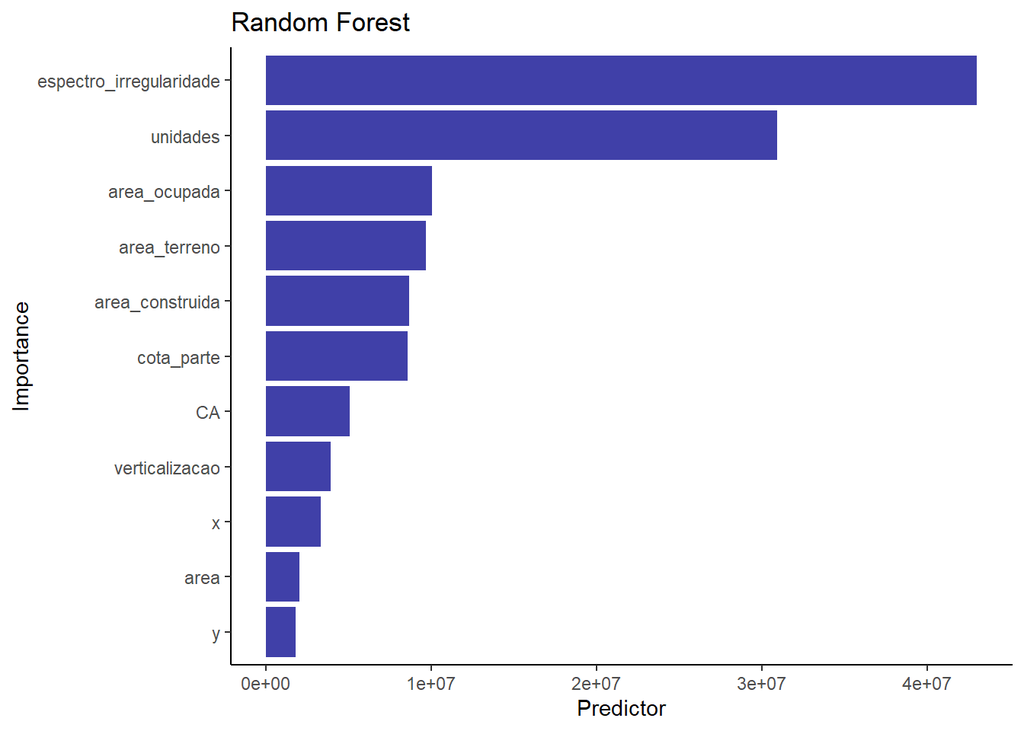

```r
rf_model_rest <- ranger::ranger(densidade ~ .,
                     data = train %>% select(-c(populacao, domicilios)), num.trees = 5000, importance = "permutation")
rf_preds_rest <- predict(rf_model_rest, data = test)$predictions

ggplot(NULL, aes(x = rf_model_rest$variable.importance,
                 y = fct_reorder(names(rf_model_rest$variable.importance),
                                 rf_model_rest$variable.importance))) +
    geom_col(fill = "darkblue", alpha = 0.75) +
    labs(x = "Predictor", y = "Importance", title = "Random Forest") +
    theme_classic()
```

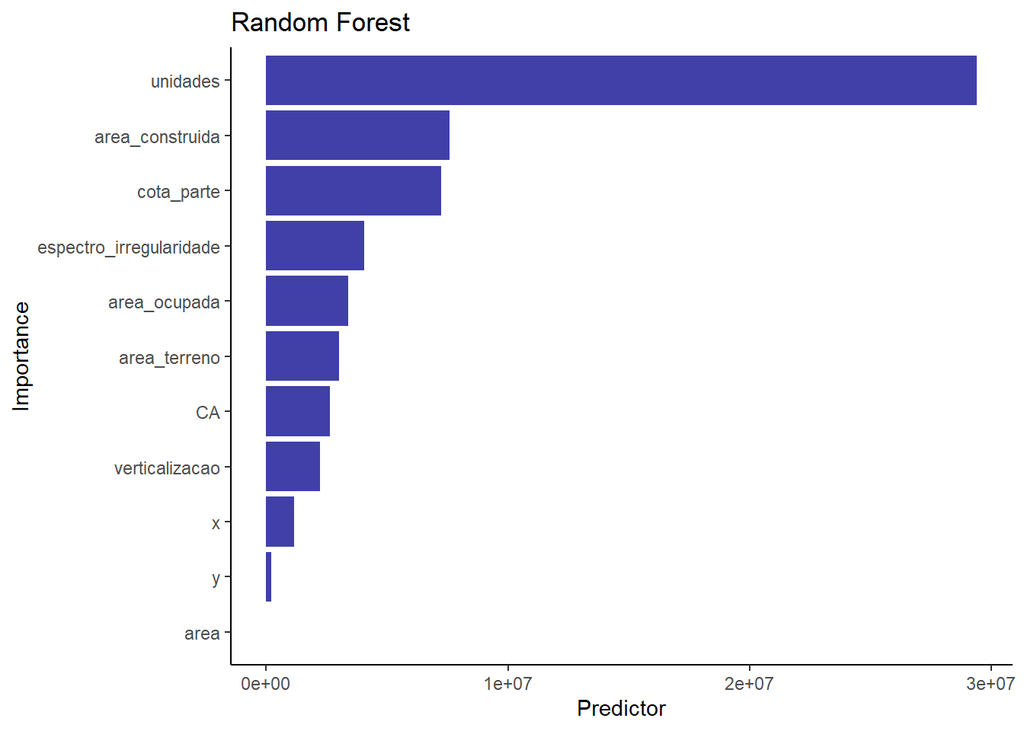

```r
rf_model_rest <- ranger::ranger(densidade ~ .,
                     data = train %>%
                       select(-c(populacao, domicilios)) %>%
                       filter(abs(espectro_irregularidade - .5) < .1),
                     num.trees = 5000, importance = "permutation")
rf_preds_rest <- predict(rf_model_rest, data = test)$predictions

ggplot(NULL, aes(x = rf_model_rest$variable.importance,
                 y = fct_reorder(names(rf_model_rest$variable.importance),
                                 rf_model_rest$variable.importance))) +
    geom_col(fill = "darkblue", alpha = 0.75) +
    labs(x = "Predictor", y = "Importance", title = "Random Forest") +
    theme_classic()
```

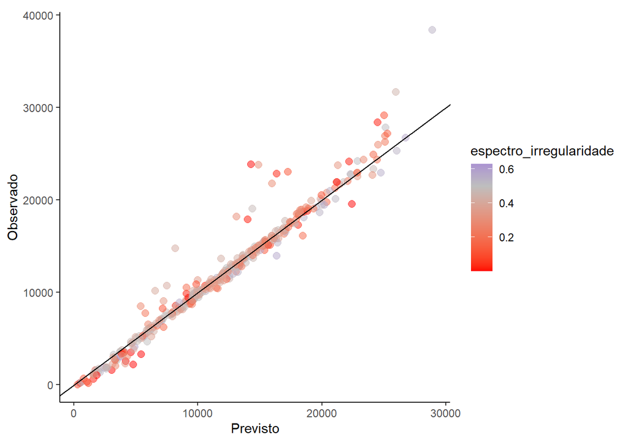

```r
ggplot(data = tibble(x = rf_preds_all, y = test$densidade, espectro_irregularidade = test$espectro_irregularidade)) +
  geom_point(aes(x = x, y = y, color = espectro_irregularidade), alpha = .5, size = 2.5) +
  scale_color_gradient2(high = "blue", low = "red", mid = "grey", midpoint = .5) +
  # coord_cartesian(xlim = c(0, .1), ylim = c(0, .1)) +
  geom_abline(slope = 1) +
  labs(x = "Previsto", y = "Observado") +
  theme_classic() +
  theme(aspect.ratio = 1)
```